# py_pandas

[Return to Data Page](https://social-lorax.github.io/guides/i2.html)

[figure not shown]

```python
#pip install gapminder
```

```python
import pandas as pd
import numpy as np
import geopandas as gpd
import datetime
import seaborn as sns
from matplotlib import pyplot as plt
%matplotlib inline

from  gapminder import gapminder
```

[figure not shown]

# Checking Data

### Contents

`.head()` returns the first few rows (the “head” of the DataFrame)

```python
gapminder.head()
```

|  | country | continent | year | lifeExp | pop | gdpPercap |
| --- | --- | --- | --- | --- | --- | --- |
| 0 | Afghanistan | Asia | 1952 | 28.801 | 8425333 | 779.445314 |
| 1 | Afghanistan | Asia | 1957 | 30.332 | 9240934 | 820.853030 |
| 2 | Afghanistan | Asia | 1962 | 31.997 | 10267083 | 853.100710 |
| 3 | Afghanistan | Asia | 1967 | 34.020 | 11537966 | 836.197138 |
| 4 | Afghanistan | Asia | 1972 | 36.088 | 13079460 | 739.981106 |

`.info()` shows information on each of the columns, such as the data type and number of missing values

```python
gapminder.info()
```

```
<class 'pandas.core.frame.DataFrame'>
RangeIndex: 1704 entries, 0 to 1703
Data columns (total 6 columns):
 #   Column     Non-Null Count  Dtype
---  ------     --------------  -----
 0   country    1704 non-null   object
 1   continent  1704 non-null   object
 2   year       1704 non-null   int64
 3   lifeExp    1704 non-null   float64
 4   pop        1704 non-null   int64
 5   gdpPercap  1704 non-null   float64
dtypes: float64(2), int64(2), object(2)
memory usage: 80.0+ KB
```

`.shape` returns the number of rows and columns of the DataFrame

```python
gapminder.shape
```

```
(1704, 6)
```

`.columns` returns an index of column names

```python
gapminder.columns
```

```
Index(['country', 'continent', 'year', 'lifeExp', 'pop', 'gdpPercap'], dtype='object')
```

`.unique()` gives a list of all of the unique values in a specified column

```python
gapminder.continent.unique()
```

```
array(['Asia', 'Europe', 'Africa', 'Americas', 'Oceania'], dtype=object)
```

### Validating

```python
total_cases = len(gapminder)
```

```python
#Number of cases with unreasonable life expectancies
valid_life = (gapminder["lifeExp"] > 20) & (gapminder["lifeExp"] < 100)
len(gapminder[valid_life]) - total_cases
```

```
0
```

```python
#Number of cases with unreasonable populations
valid_pop = (gapminder["gdpPercap"] > 100) & (gapminder["pop"] < 1000000000000)
len(gapminder[valid_pop]) - total_cases
```

```
0
```

```python
#Filtering out uncreasonable cases
gapminder = gapminder[valid_life & valid_pop]
```

### Summarizing

`.describe()` calculates a few summary statistics for each column

```python
gapminder.describe()
```

|  | year | lifeExp | pop | gdpPercap |
| --- | --- | --- | --- | --- |
| count | 1704.00000 | 1704.000000 | 1.704000e+03 | 1704.000000 |
| mean | 1979.50000 | 59.474439 | 2.960121e+07 | 7215.327081 |
| std | 17.26533 | 12.917107 | 1.061579e+08 | 9857.454543 |
| min | 1952.00000 | 23.599000 | 6.001100e+04 | 241.165876 |
| 25% | 1965.75000 | 48.198000 | 2.793664e+06 | 1202.060309 |
| 50% | 1979.50000 | 60.712500 | 7.023596e+06 | 3531.846988 |
| 75% | 1993.25000 | 70.845500 | 1.958522e+07 | 9325.462346 |
| max | 2007.00000 | 82.603000 | 1.318683e+09 | 113523.132900 |

`.value_counts()` counts categorical variables, with the argument `noramlize = True` providing the relative frequency

```python
gapminder[gapminder["year"] == 2007]["continent"].value_counts()
```

```
Africa      52
Asia        33
Europe      30
Americas    25
Oceania      2
Name: continent, dtype: int64
```

```python
gapminder[gapminder["year"] == 2007]["continent"].value_counts(normalize = True)
```

```
Africa      0.366197
Asia        0.232394
Europe      0.211268
Americas    0.176056
Oceania     0.014085
Name: continent, dtype: float64
```

`.pivot_table()` can be used to make crosstabs

```python
conditions = [(gapminder["pop"].lt(4508000)),
             (gapminder["pop"].ge(4508000) & gapminder["pop"].le(31210000)),
             (gapminder["pop"].gt(31210000))]

choices = ["small", "average", "large"]

gapminder["size"] = np.select(conditions, choices)


gapminder[gapminder["year"] == 2007].pivot_table(values = "lifeExp",
                                                 index = "continent",
                                                 columns = "size",
                                                 aggfunc = len,
                                                 fill_value = 0,
                                                 margins = True)
```

| size continent | average | large | small | All |
| --- | --- | --- | --- | --- |
| Africa | 25 | 10 | 17 | 52 |
| Americas | 13 | 6 | 6 | 25 |
| Asia | 14 | 13 | 6 | 33 |
| Europe | 17 | 7 | 6 | 30 |
| Oceania | 1 | 0 | 1 | 2 |
| All | 70 | 36 | 36 | 142 |

`.groupby()` allows you to get summary statistics for grouped data

```python
gapminder[gapminder["year"] > 1990].groupby(["continent", "year"])["lifeExp"].median()
```

```
continent  year
Africa     1992    52.4290
           1997    52.7590
           2002    51.2355
           2007    52.9265
Americas   1992    69.8620
           1997    72.1460
           2002    72.0470
           2007    72.8990
Asia       1992    68.6900
           1997    70.2650
           2002    71.0280
           2007    72.3960
Europe     1992    75.4510
           1997    76.1160
           2002    77.5365
           2007    78.6085
Oceania    1992    76.9450
           1997    78.1900
           2002    79.7400
           2007    80.7195
Name: lifeExp, dtype: float64
```

```python
gapminder[gapminder["year"] > 1990].groupby(["continent", "year"]).agg({'country':'count',
                                                                        'pop':'sum',
                                                                        'lifeExp':'mean',
                                                                        'gdpPercap': 'median'})
```

| continent | year | country | pop | lifeExp | gdpPercap |
| --- | --- | --- | --- | --- | --- |
| Africa | 1992 | 52 | 659081517 | 53.629577 | 1161.631357 |
|  | 1997 | 52 | 743832984 | 53.598269 | 1179.883114 |
|  | 2002 | 52 | 833723916 | 53.325231 | 1215.683217 |
|  | 2007 | 52 | 929539692 | 54.806038 | 1452.267078 |
| Americas | 1992 | 25 | 739274104 | 69.568360 | 6618.743050 |
|  | 1997 | 25 | 796900410 | 71.150480 | 7113.692252 |
|  | 2002 | 25 | 849772762 | 72.422040 | 6994.774861 |
|  | 2007 | 25 | 898871184 | 73.608120 | 8948.102923 |
| Asia | 1992 | 33 | 3133292191 | 66.537212 | 3726.063507 |
|  | 1997 | 33 | 3383285500 | 68.020515 | 3645.379572 |
|  | 2002 | 33 | 3601802203 | 69.233879 | 4090.925331 |
|  | 2007 | 33 | 3811953827 | 70.728485 | 4471.061906 |
| Europe | 1992 | 30 | 558142797 | 74.440100 | 17550.155945 |
|  | 1997 | 30 | 568944148 | 75.505167 | 19596.498550 |
|  | 2002 | 30 | 578223869 | 76.700600 | 23674.863230 |
|  | 2007 | 30 | 586098529 | 77.648600 | 28054.065790 |
| Oceania | 1992 | 2 | 20919651 | 76.945000 | 20894.045885 |
|  | 1997 | 2 | 22241430 | 78.190000 | 24024.175170 |
|  | 2002 | 2 | 23454829 | 79.740000 | 26938.778040 |
|  | 2007 | 2 | 24549947 | 80.719500 | 29810.188275 |

`.corr()` generates a correlation table

```python
gapminder.corr()
```

|  | year | lifeExp | pop | gdpPercap |
| --- | --- | --- | --- | --- |
| year | 1.000000 | 0.435611 | 0.082308 | 0.227318 |
| lifeExp | 0.435611 | 1.000000 | 0.064955 | 0.583706 |
| pop | 0.082308 | 0.064955 | 1.000000 | -0.025600 |
| gdpPercap | 0.227318 | 0.583706 | -0.025600 | 1.000000 |

### Missing Values

`.isna().sum()` returns the number of missing observations per column

```python
gapminder.isna().sum()
```

```
country      0
continent    0
year         0
lifeExp      0
pop          0
gdpPercap    0
size         0
dtype: int64
```

`.dropna()` removes entire rows with missing values

```python
gapminder.dropna(inplace = True)
```

`subset =` will only drop if the missing values are in the specified column

```python
gapminder.dropna(subset = ['country'], inplace = True)
```

`.fillna()` replaces all missing values with the specified value

```python
gapminder.fillna(0, inplace = True)
```

```python
gapminder["country"] = gapminder["country"].fillna("Missing")
```

### Duplicates

`.drop_duplicates()` will keep only the first instance of each value in the column(s) specified

```python
gapminder.drop_duplicates("continent")
```

|  | country | continent | year | lifeExp | pop | gdpPercap | size |
| --- | --- | --- | --- | --- | --- | --- | --- |
| 0 | Afghanistan | Asia | 1952 | 28.801 | 8425333 | 779.445314 | average |
| 12 | Albania | Europe | 1952 | 55.230 | 1282697 | 1601.056136 | small |
| 24 | Algeria | Africa | 1952 | 43.077 | 9279525 | 2449.008185 | average |
| 48 | Argentina | Americas | 1952 | 62.485 | 17876956 | 5911.315053 | average |
| 60 | Australia | Oceania | 1952 | 69.120 | 8691212 | 10039.595640 | average |

```python
gapminder.drop_duplicates(["continent", "year"]).head()
```

|  | country | continent | year | lifeExp | pop | gdpPercap | size |
| --- | --- | --- | --- | --- | --- | --- | --- |
| 0 | Afghanistan | Asia | 1952 | 28.801 | 8425333 | 779.445314 | average |
| 1 | Afghanistan | Asia | 1957 | 30.332 | 9240934 | 820.853030 | average |
| 2 | Afghanistan | Asia | 1962 | 31.997 | 10267083 | 853.100710 | average |
| 3 | Afghanistan | Asia | 1967 | 34.020 | 11537966 | 836.197138 | average |
| 4 | Afghanistan | Asia | 1972 | 36.088 | 13079460 | 739.981106 | average |

### Outliers

First start with a histogram using `plt.hist()`. (We can already see what may be two high outliers)

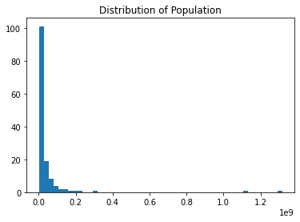

```python
gap_07 = gapminder[gapminder["year"] == 2007]

plt.hist(gap_07["pop"], bins = 50)
plt.title("Distribution of Population")
plt.show()
```

Transform into a log-scale histogram if needed.

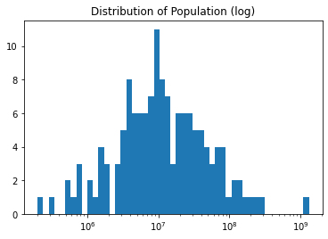

```python
def plot_loghist(x, bins):
  #function for plotting a log-scale histogram
  #it ensures log-scale binning and label on the original scale
    logbins = np.logspace(np.log10(x.min()),np.log10(x.max()),bins)
    plt.hist(x, bins=logbins)
    plt.xscale('log')

plot_loghist(gap_07["pop"], bins = 50)
plt.title("Distribution of Population (log)")
plt.show()
```

Next use `plt.boxplot()` to see the 25th, 75th, and median plotted with observations about a defined percentile plotted as circles. Here we see the two high points, but also the two lowest points.

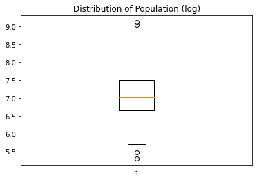

```python
plt.boxplot(np.log10(gap_07["pop"]), whis=[1, 99]) #whiskers will by the 1% and 99%
plt.title("Distribution of Population (log)")
plt.show()
```

We can then pull these observations to validate (or drop)

```python
gap_07[gap_07["pop"] < gap_07["pop"].quantile(0.01)][["country", "continent", "pop"]]
```

|  | country | continent | pop |
| --- | --- | --- | --- |
| 695 | Iceland | Europe | 301931 |
| 1307 | Sao Tome and Principe | Africa | 199579 |

```python
gap_07[gap_07["pop"] > gap_07["pop"].quantile(0.99)][["country", "continent", "pop"]]
```

|  | country | continent | pop |
| --- | --- | --- | --- |
| 299 | China | Asia | 1318683096 |
| 707 | India | Asia | 1110396331 |

Alternative, we can use a standard definition of "mean +/- 3 standard deviations" as a threshhold for outliers.

```python
stdev = np.std(gap_07["pop"])
mean = np.mean(gap_07["pop"])
high_out = mean + (3 * stdev)
low_out = mean - (3 * stdev)

gap_07[(gap_07["pop"] < low_out) | (gap_07["pop"] > high_out)][["country", "continent", "pop"]]
```

|  | country | continent | pop |
| --- | --- | --- | --- |
| 299 | China | Asia | 1318683096 |
| 707 | India | Asia | 1110396331 |

We can now validate that we *were* expecting these and that they are correct, but in other cases we could drop them.

[figure not shown]

# Wrangling

### Sorting

`.sort_values()` sorts based on a column (ascending), the argument `ascending = False` returns descending sorting

```python
gapminder.sort_values(["country", "year"], ascending = [True, False]).head()
```

|  | country | continent | year | lifeExp | pop | gdpPercap | size |
| --- | --- | --- | --- | --- | --- | --- | --- |
| 11 | Afghanistan | Asia | 2007 | 43.828 | 31889923 | 974.580338 | large |
| 10 | Afghanistan | Asia | 2002 | 42.129 | 25268405 | 726.734055 | average |
| 9 | Afghanistan | Asia | 1997 | 41.763 | 22227415 | 635.341351 | average |
| 8 | Afghanistan | Asia | 1992 | 41.674 | 16317921 | 649.341395 | average |
| 7 | Afghanistan | Asia | 1987 | 40.822 | 13867957 | 852.395945 | average |

### Subsetting

```python
gapminder[["country"]].head()
```

|  | country |
| --- | --- |
| 0 | Afghanistan |
| 1 | Afghanistan |
| 2 | Afghanistan |
| 3 | Afghanistan |
| 4 | Afghanistan |

```python
gapminder[["country", "year", "lifeExp"]].head()
```

|  | country | year | lifeExp |
| --- | --- | --- | --- |
| 0 | Afghanistan | 1952 | 28.801 |
| 1 | Afghanistan | 1957 | 30.332 |
| 2 | Afghanistan | 1962 | 31.997 |
| 3 | Afghanistan | 1967 | 34.020 |
| 4 | Afghanistan | 1972 | 36.088 |

```python
gapminder.loc[[1, 3, 5], ["country", "year", "lifeExp"]]
```

|  | country | year | lifeExp |
| --- | --- | --- | --- |
| 1 | Afghanistan | 1957 | 30.332 |
| 3 | Afghanistan | 1967 | 34.020 |
| 5 | Afghanistan | 1977 | 38.438 |

### Indexing

```python
gapminder_ind = gapminder[gapminder["year"] > 2000].set_index("continent")

gapminder_ind.loc["Asia"].head()
```

| continent | country | year | lifeExp | pop | gdpPercap | size |
| --- | --- | --- | --- | --- | --- | --- |
| Asia | Afghanistan | 2002 | 42.129 | 25268405 | 726.734055 | average |
| Asia | Afghanistan | 2007 | 43.828 | 31889923 | 974.580338 | large |
| Asia | Bahrain | 2002 | 74.795 | 656397 | 23403.559270 | small |
| Asia | Bahrain | 2007 | 75.635 | 708573 | 29796.048340 | small |
| Asia | Bangladesh | 2002 | 62.013 | 135656790 | 1136.390430 | large |

```python
gapminder_ind = gapminder[gapminder["year"] > 2000].set_index(["continent", "country"])

gapminder_ind.loc[[("Asia", "Japan"),("Americas", "United States")]]
```

| continent | country | year | lifeExp | pop | gdpPercap | size |
| --- | --- | --- | --- | --- | --- | --- |
| Asia | Japan | 2002 | 82.000 | 127065841 | 28604.59190 | large |
|  | Japan | 2007 | 82.603 | 127467972 | 31656.06806 | large |
| Americas | United States | 2002 | 77.310 | 287675526 | 39097.09955 | large |
|  | United States | 2007 | 78.242 | 301139947 | 42951.65309 | large |

```python
gapminder_ind.loc[[("Asia", "Japan"),("Americas", "United States")]].reset_index()
```

|  | continent | country | year | lifeExp | pop | gdpPercap | size |
| --- | --- | --- | --- | --- | --- | --- | --- |
| 0 | Asia | Japan | 2002 | 82.000 | 127065841 | 28604.59190 | large |
| 1 | Asia | Japan | 2007 | 82.603 | 127467972 | 31656.06806 | large |
| 2 | Americas | United States | 2002 | 77.310 | 287675526 | 39097.09955 | large |
| 3 | Americas | United States | 2007 | 78.242 | 301139947 | 42951.65309 | large |

### Filtering

```python
gapminder[gapminder["lifeExp"] > 82]
```

|  | country | continent | year | lifeExp | pop | gdpPercap | size |
| --- | --- | --- | --- | --- | --- | --- | --- |
| 671 | Hong Kong, China | Asia | 2007 | 82.208 | 6980412 | 39724.97867 | average |
| 803 | Japan | Asia | 2007 | 82.603 | 127467972 | 31656.06806 | large |

```python
gapminder[(gapminder["lifeExp"] > 82) | (gapminder["gdpPercap"] > 100000)]
```

|  | country | continent | year | lifeExp | pop | gdpPercap | size |
| --- | --- | --- | --- | --- | --- | --- | --- |
| 671 | Hong Kong, China | Asia | 2007 | 82.208 | 6980412 | 39724.97867 | average |
| 803 | Japan | Asia | 2007 | 82.603 | 127467972 | 31656.06806 | large |
| 852 | Kuwait | Asia | 1952 | 55.565 | 160000 | 108382.35290 | small |
| 853 | Kuwait | Asia | 1957 | 58.033 | 212846 | 113523.13290 | small |
| 856 | Kuwait | Asia | 1972 | 67.712 | 841934 | 109347.86700 | small |

```python
gapminder[gapminder["continent"].isin(["Americas", "Oceania"])].head()
```

|  | country | continent | year | lifeExp | pop | gdpPercap | size |
| --- | --- | --- | --- | --- | --- | --- | --- |
| 48 | Argentina | Americas | 1952 | 62.485 | 17876956 | 5911.315053 | average |
| 49 | Argentina | Americas | 1957 | 64.399 | 19610538 | 6856.856212 | average |
| 50 | Argentina | Americas | 1962 | 65.142 | 21283783 | 7133.166023 | average |
| 51 | Argentina | Americas | 1967 | 65.634 | 22934225 | 8052.953021 | average |
| 52 | Argentina | Americas | 1972 | 67.065 | 24779799 | 9443.038526 | average |

[figure not shown]

# Columns

### New

```python
gapminder["gdp"] = gapminder["gdpPercap"] * gapminder["pop"]

gapminder.head()
```

|  | country | continent | year | lifeExp | pop | gdpPercap | size | gdp |
| --- | --- | --- | --- | --- | --- | --- | --- | --- |
| 0 | Afghanistan | Asia | 1952 | 28.801 | 8425333 | 779.445314 | average | 6.567086e+09 |
| 1 | Afghanistan | Asia | 1957 | 30.332 | 9240934 | 820.853030 | average | 7.585449e+09 |
| 2 | Afghanistan | Asia | 1962 | 31.997 | 10267083 | 853.100710 | average | 8.758856e+09 |
| 3 | Afghanistan | Asia | 1967 | 34.020 | 11537966 | 836.197138 | average | 9.648014e+09 |
| 4 | Afghanistan | Asia | 1972 | 36.088 | 13079460 | 739.981106 | average | 9.678553e+09 |

### Change Type

Use `.astype("str")` for strings...

```python
gapminder['gdp'] = gapminder['gdp'].astype("str")

gapminder.head()
```

|  | country | continent | year | lifeExp | pop | gdpPercap | size | gdp |
| --- | --- | --- | --- | --- | --- | --- | --- | --- |
| 0 | Afghanistan | Asia | 1952 | 28.801 | 8425333 | 779.445314 | average | 6567086329.952229 |
| 1 | Afghanistan | Asia | 1957 | 30.332 | 9240934 | 820.853030 | average | 7585448670.233646 |
| 2 | Afghanistan | Asia | 1962 | 31.997 | 10267083 | 853.100710 | average | 8758855796.92893 |
| 3 | Afghanistan | Asia | 1967 | 34.020 | 11537966 | 836.197138 | average | 9648014149.848902 |
| 4 | Afghanistan | Asia | 1972 | 36.088 | 13079460 | 739.981106 | average | 9678553274.066868 |

... and `pd.to_numeric()` for numeric

`errors = 'ignore'` will return the original value

`errors = 'coerce'` will return a null value

```python
gapminder['gdp'] = pd.to_numeric(gapminder['gdp'])

gapminder.head()
```

|  | country | continent | year | lifeExp | pop | gdpPercap | size | gdp |
| --- | --- | --- | --- | --- | --- | --- | --- | --- |
| 0 | Afghanistan | Asia | 1952 | 28.801 | 8425333 | 779.445314 | average | 6.567086e+09 |
| 1 | Afghanistan | Asia | 1957 | 30.332 | 9240934 | 820.853030 | average | 7.585449e+09 |
| 2 | Afghanistan | Asia | 1962 | 31.997 | 10267083 | 853.100710 | average | 8.758856e+09 |
| 3 | Afghanistan | Asia | 1967 | 34.020 | 11537966 | 836.197138 | average | 9.648014e+09 |
| 4 | Afghanistan | Asia | 1972 | 36.088 | 13079460 | 739.981106 | average | 9.678553e+09 |

[figure not shown]

# Date Times

### Setting

```python
gapminder['date_year'] = pd.to_datetime(gapminder['year'], format='%Y')

gapminder.head()
```

|  | country | continent | year | lifeExp | pop | gdpPercap | size | gdp | date_year |
| --- | --- | --- | --- | --- | --- | --- | --- | --- | --- |
| 0 | Afghanistan | Asia | 1952 | 28.801 | 8425333 | 779.445314 | average | 6.567086e+09 | 1952-01-01 |
| 1 | Afghanistan | Asia | 1957 | 30.332 | 9240934 | 820.853030 | average | 7.585449e+09 | 1957-01-01 |
| 2 | Afghanistan | Asia | 1962 | 31.997 | 10267083 | 853.100710 | average | 8.758856e+09 | 1962-01-01 |
| 3 | Afghanistan | Asia | 1967 | 34.020 | 11537966 | 836.197138 | average | 9.648014e+09 | 1967-01-01 |
| 4 | Afghanistan | Asia | 1972 | 36.088 | 13079460 | 739.981106 | average | 9.678553e+09 | 1972-01-01 |

### Extracting

`dt` has:

- `dt.year`
- `dt.month`
- `dt.day`
- `dt.hour`
- `dt.minute`

```python
gapminder["month"] = gapminder["date_year"].dt.month

gapminder.head()
```

|  | country | continent | year | lifeExp | pop | gdpPercap | size | gdp | date_year | month |
| --- | --- | --- | --- | --- | --- | --- | --- | --- | --- | --- |
| 0 | Afghanistan | Asia | 1952 | 28.801 | 8425333 | 779.445314 | average | 6.567086e+09 | 1952-01-01 | 1 |
| 1 | Afghanistan | Asia | 1957 | 30.332 | 9240934 | 820.853030 | average | 7.585449e+09 | 1957-01-01 | 1 |
| 2 | Afghanistan | Asia | 1962 | 31.997 | 10267083 | 853.100710 | average | 8.758856e+09 | 1962-01-01 | 1 |
| 3 | Afghanistan | Asia | 1967 | 34.020 | 11537966 | 836.197138 | average | 9.648014e+09 | 1967-01-01 | 1 |
| 4 | Afghanistan | Asia | 1972 | 36.088 | 13079460 | 739.981106 | average | 9.678553e+09 | 1972-01-01 | 1 |

### Comparing

```python
gapminder[gapminder["date_year"] > pd.to_datetime("1990-07-04 12:01:00")].head()
```

|  | country | continent | year | lifeExp | pop | gdpPercap | size | gdp | date_year | month |
| --- | --- | --- | --- | --- | --- | --- | --- | --- | --- | --- |
| 8 | Afghanistan | Asia | 1992 | 41.674 | 16317921 | 649.341395 | average | 1.059590e+10 | 1992-01-01 | 1 |
| 9 | Afghanistan | Asia | 1997 | 41.763 | 22227415 | 635.341351 | average | 1.412200e+10 | 1997-01-01 | 1 |
| 10 | Afghanistan | Asia | 2002 | 42.129 | 25268405 | 726.734055 | average | 1.836341e+10 | 2002-01-01 | 1 |
| 11 | Afghanistan | Asia | 2007 | 43.828 | 31889923 | 974.580338 | large | 3.107929e+10 | 2007-01-01 | 1 |
| 20 | Albania | Europe | 1992 | 71.581 | 3326498 | 2497.437901 | small | 8.307722e+09 | 1992-01-01 | 1 |

[figure not shown]

# Visualizing

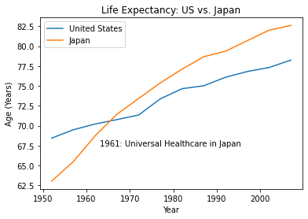

```python
us_life = gapminder[gapminder.country == "United States"][["country", "year", "lifeExp"]]
japan_life = gapminder[gapminder.country == "Japan"][["country", "year", "lifeExp"]]

plt.plot(us_life.year, us_life.lifeExp, label = "United States")

plt.plot(japan_life.year, japan_life.lifeExp, label = "Japan")

plt.xlabel("Year")
plt.ylabel("Age (Years)")
plt.title("Life Expectancy: US vs. Japan")

plt.text(1963, 67.5, "1961: Universal Healthcare in Japan")

plt.legend()

plt.show()
```

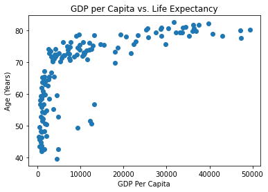

```python
gap_07 = gapminder[gapminder.year == 2007]

plt.scatter(gap_07.gdpPercap, gap_07.lifeExp)

plt.xlabel("GDP Per Capita")
plt.ylabel("Age (Years)")
plt.title("GDP per Capita vs. Life Expectancy")

plt.show()
```